# Final Report

### Goal of the Project

I set out to build a movie recommender that learns from users’ past ratings and content metadata. By testing collaborative filtering, content-based filtering, and a simple ensemble, I aim to show how combining different signals can boost both coverage and ranking quality.

### Background Knowledge

Personalized recommendations power platforms like Netflix and Hulu. A strong recommender reduces churn and increases engagement by surfacing films users will actually enjoy. I tackle this real-world problem to deepen my understanding of collaborative, content-based, and hybrid approaches in a large, sparse ratings dataset.

### Credible Sources

The development and study of recommendation systems have been extensively explored in academic literature and are critical for understanding how these systems can be designed and optimized. Below are some relevant sources to provide deeper insights into recommendation algorithms and their application in the entertainment industry:

1. **Ricci, F., Rokach, L., & Shapira, B. (2015). *Recommender Systems Handbook*. Springer.**
   - This book provides a comprehensive overview of recommendation systems, including collaborative filtering, content-based filtering, and hybrid approaches. It also covers the challenges faced in recommendation systems and various evaluation methods.
2. **Jannach, D., & Adomavicius, G. (2016). *Recommender Systems: Challenges and Research Opportunities*. AI Magazine, 37(3), 13-25.**
   - This article outlines challenges faced in building recommendation systems and discusses emerging trends and research opportunities in the field.
3. **Bobadilla, J., Ortega, F., Hernando, A., & Gutiérrez, A. (2013). *Recommender Systems Survey*. Knowledge-Based Systems, 46, 109-132.**
   - This paper surveys various recommendation algorithms and evaluates their effectiveness in different contexts, providing an understanding of their strengths and weaknesses.
4. **Yao, Y., & Lee, Y. (2020). *A Survey on Content-Based Recommender Systems*. Journal of Computer Science & Technology, 35(3), 429-448.**
   - This paper focuses on content-based recommender systems, providing in-depth technical details and applications of these systems in different domains, including the entertainment industry.

### Dataset Selection

- **Link**: [MovieLens 20M Dataset on Kaggle](https://www.kaggle.com)

### Detailed Data Description

Contains user ratings for different movies.

- `userId`: A unique identifier for each user.
- `movieId`: The ID of the movie that was rated.
- `rating`: The rating given by the user on a scale from **0.5 to 5.0**, in increments of 0.5.
- `timestamp`: The time the rating was given, stored as a Unix timestamp (seconds since January 1, 1970).

#### **3. Tag Dataset**

Contains user-assigned tags for movies, which can provide additional context beyond genres.

- `userId`: The ID of the user who added the tag.
- `movieId`: The movie to which the tag applies.
- `tag`: A free-text label assigned by the user (e.g., "Mind-blowing," "Slow burn").
- `timestamp`: The time the tag was added, stored as a Unix timestamp.

#### **4. Link Dataset**

Provides mappings between **movieId** and external databases like IMDb and TMDb.

- `movieId`: The movie's ID within this dataset.
- `imdbId`: The corresponding IMDb ID, which can be used to fetch additional metadata from IMDb.
- `tmdbId`: The corresponding TMDb (The Movie Database) ID, which can be used for movie posters, descriptions, and cast details.

#### **5. Genome Scores Dataset**

Contains scores that measure how relevant different **tags** are to each movie.

- `movieId`: The ID of the movie being evaluated.
- `tagId`: A unique identifier for a specific tag.
- `relevance`: A numerical score (0 to 1) indicating how strongly the tag applies to the movie (1 = highly relevant, 0 = not relevant).

#### **6. Genome Tags Dataset**

Provides the actual **text descriptions** for the **tagId** values in the Genome Scores dataset.

- `tagId`: A unique identifier for a tag.
- `tag`: The actual word or phrase that describes the movie (e.g., "Based on a true story," "Dark humor").

#### **How is this useful for my recommendation system?**

- **Movie dataset**: Provides essential movie details (title and genres).
- **Ratings dataset**: Core data for collaborative filtering (users’ ratings of movies).
- **Tag dataset & Genome Scores**: Useful for content-based filtering (helps match movies with similar themes).
- **Link dataset**: Allows enrichment of data with IMDb/TMDb metadata.

## Code

```python
import pandas as pd
import numpy as np
import warnings
warnings.filterwarnings('ignore')
```

### Import Data

```python
movie = pd.read_csv('movie.csv')  # Movie metadata
link = pd.read_csv('link.csv', dtype={'tmdbId': 'Int64'})
genome_scores = pd.read_csv('genome_scores.csv')  # Movie genome scores
genome_tags = pd.read_csv('genome_tags.csv')  # Movie genome tags
# Read ratings dataset without the timestamp column
rating = pd.read_csv('rating.csv', usecols=['userId', 'movieId', 'rating'])
# Read tags dataset without the timestamp column
tag = pd.read_csv('tag.csv', usecols=[ 'movieId', 'tag'])
```

### Check datasets

```python
# Display the first few rows of each dataset to inspect their structure
print("Movie Dataset:")
print(movie.head())

print("\nLink Dataset:")
print(link.head())

print("\nGenome Scores Dataset:")
print(genome_scores.head())

print("\nGenome Tags Dataset:")
print(genome_tags.head())

print("\nRating Dataset:")
print(rating.head())

print("\nTag Dataset:")
print(tag.head())
```

```
Movie Dataset:
   movieId                               title  \
0        1                    Toy Story (1995)
1        2                      Jumanji (1995)
2        3             Grumpier Old Men (1995)
3        4            Waiting to Exhale (1995)
4        5  Father of the Bride Part II (1995)

                                        genres
0  Adventure|Animation|Children|Comedy|Fantasy
1                   Adventure|Children|Fantasy
2                               Comedy|Romance
3                         Comedy|Drama|Romance
4                                       Comedy

Link Dataset:
   movieId  imdbId  tmdbId
0        1  114709     862
1        2  113497    8844
2        3  113228   15602
3        4  114885   31357
4        5  113041   11862

Genome Scores Dataset:
   movieId  tagId  relevance
0        1      1    0.02500
1        1      2    0.02500
2        1      3    0.05775
3        1      4    0.09675
4        1      5    0.14675

Genome Tags Dataset:
   tagId           tag
0      1           007
1      2  007 (series)
2      3  18th century
3      4         1920s
4      5         1930s

Rating Dataset:
   userId  movieId  rating
0       1        2     3.5
1       1       29     3.5
2       1       32     3.5
3       1       47     3.5
4       1       50     3.5

Tag Dataset:
   movieId            tag
0     4141    Mark Waters
1      208      dark hero
2      353      dark hero
3      521  noir thriller
4      592      dark hero
```

# Handling Missing Values

```python
# Check for missing values in each dataset
print("Movie dataset missing values:")
print(movie.isnull().sum())  # Check for missing values in movies dataset

print("\nTag dataset missing values:")
print(tag.isnull().sum())

print("\nLink dataset missing values:")
print(link.isnull().sum())

print("\nRating dataset missing values:")
print(rating.isnull().sum())

print("\nGenome Scores dataset missing values:")
print(genome_scores.isnull().sum())

print("\nGenome Tags dataset missing values:")
print(genome_tags.isnull().sum())
```

```
Movie dataset missing values:
movieId    0
title      0
genres     0
dtype: int64

Tag dataset missing values:
movieId     0
tag        16
dtype: int64

Link dataset missing values:
movieId      0
imdbId       0
tmdbId     252
dtype: int64

Rating dataset missing values:
userId     0
movieId    0
rating     0
dtype: int64

Genome Scores dataset missing values:
movieId      0
tagId        0
relevance    0
dtype: int64

Genome Tags dataset missing values:
tagId    0
tag      0
dtype: int64
```

```python
# Impute missing values for the 'tag' dataset (missing 'tag' entries with 'No Tags')
tag['tag'] = tag['tag'].fillna('No Tags')

# Check for missing values after imputation
print("Missing values after imputation:")
print(f"Tag dataset missing values:\n{tag.isnull().sum()}\n")
```

```
Missing values after imputation:
Tag dataset missing values:
movieId    0
tag        0
dtype: int64
```

# Merging Datasets and Handling Missing Values

This section describes how all relevant datasets were consolidated into a single, enriched `final_df`, with missing data handled appropriately.

#### Step-by-Step Merging

1. **Movies and Ratings were merged**  
   The `movie` and `rating` datasets were joined on `movieId`, incorporating user-generated ratings for each movie.
2. **External Links were added**  
   The `link` dataset (containing IMDb and TMDB IDs) was merged to support potential integration with external APIs or metadata.
3. **Genome Tags and Scores were combined**  
   The `genome_scores` and `genome_tags` DataFrames were joined on `tagId`, resulting in `genome_merged`, which contains both tag names and relevance scores per movie.
4. **Movie Metadata was constructed**
   - A dictionary mapping each `movieId` to a list of `(tag, relevance)` tuples was created.
   - Genres were split from pipe-separated strings into lists.
   - Both metadata sources were merged into `movie_metadata_df`.
5. **User-Contributed Tags were aggregated**  
   The `tag` dataset was grouped by `movieId` into lists and merged as `movie_metadata_df_tags`.
6. **Final Merge into Main DataFrame**
   - The original `genres` column was dropped.
   - `movie_metadata_df` and `movie_metadata_df_tags` were merged into `merged_df`, producing the comprehensive `final_df`.

### Missing Value Handling

- **Essential Fields**:  
  Rows missing `userId` or `rating` were dropped, as these fields are critical for collaborative filtering.
- **Missing `tmdbId`**:  
  A placeholder value of `-1` was assigned to indicate missing linkage without disrupting numeric operations.
- **Missing Tags and Genres**:  
  The columns `tag_relevance`, `genres_list`, and `tags_list` were filled with empty lists to maintain a uniform structure for downstream feature extraction.

### Rating Aggregation Features

- **Average Rating and Rating Count**  
  The **mean rating** and **total number of ratings** were computed per movie and merged back into `final_df` as `avg_rating` and `rating_count`.

#### Rating & Tag Lookup Features

  ```
  movie_tag_dict = { movieId: { tag: relevance, … }, … }
  ```

```python
# Merge movie with rating
merged_df = pd.merge(movie, rating, on='movieId', how='left')

print("Merged movie and rating. Shape:", merged_df.shape)
```

```
Merged movie and rating. Shape: (20000797, 5)
```

```python
# Merge with link
merged_df = pd.merge(merged_df, link, on='movieId', how='left')

print("Merged with link. Shape:", merged_df.shape)
```

```
Merged with link. Shape: (20000797, 7)
```

```python
# Merge genome_scores and genome_tags on tagId
genome_merged = genome_scores.merge(genome_tags, on='tagId', how='left')

# Check the first few rows to confirm the merge worked
genome_merged.head()
```

|  | movieId | tagId | relevance | tag |
| --- | --- | --- | --- | --- |
| 0 | 1 | 1 | 0.02500 | 007 |
| 1 | 1 | 2 | 0.02500 | 007 (series) |
| 2 | 1 | 3 | 0.05775 | 18th century |
| 3 | 1 | 4 | 0.09675 | 1920s |
| 4 | 1 | 5 | 0.14675 | 1930s |

```python
# Rename tag to avoid confusion
genome_merged.rename(columns={'tag': 'genome_tag'}, inplace=True)
```

```python
print(genome_merged.head())
```

```
   movieId  tagId  relevance    genome_tag
0        1      1    0.02500           007
1        1      2    0.02500  007 (series)
2        1      3    0.05775  18th century
3        1      4    0.09675         1920s
4        1      5    0.14675         1930s
```

```python
# Group by movieId and create a dictionary where movieId maps to a list of (tag, relevance) tuples

movie_tag_relevance_dict = (
    genome_merged.groupby('movieId')
    .apply(lambda x: list(zip(x['genome_tag'], x['relevance'])))
    .to_dict()
)
```

```python
# Convert genres into a list for each movie
movie_genres = movie.groupby('movieId')['genres'].apply(lambda x: x.iloc[0].split('|')).to_dict()

# Combine tags and genres into a dictionary
movie_metadata = {
    movie_id: {
        'tag_relevance': movie_tag_relevance_dict.get(movie_id, []),  # Tags with relevance
        'genres_list': movie_genres.get(movie_id, [])  # List of genres
    }
    for movie_id in genome_merged['movieId'].unique()
}

# Create DataFrame with movieId, tags, and genres
movie_metadata_df = pd.DataFrame.from_dict(movie_metadata, orient='index')
```

```python
# Convert 'tag' into a list of tags for each movieId (from long format)
movie_tags_list = tag.groupby('movieId')['tag'].apply(lambda x: x.tolist()).to_dict()

# Combine tags into a dictionary
movie_metadata_tags = {
    movie_id: {
        'tags_list': movie_tags_list.get(movie_id, [])  # List of tags (long format)
    }
    for movie_id in merged_df['movieId'].unique()
}

# Create DataFrame with movieId, tags, and genres
movie_metadata_df_tags = pd.DataFrame.from_dict(movie_metadata_tags, orient='index')

# Remove the original genres column from merged_df (if necessary)
merged_df = merged_df.drop(columns=['genres'])

# Merge metadata (tags and genres) with your main dataset
final_df = merged_df.merge(movie_metadata_df, left_on='movieId', right_index=True, how='left')
final_df = final_df.merge(movie_metadata_df_tags, left_on='movieId', right_index=True, how='left')
```

```python
final_df.head()
```

|  | movieId | title | userId | rating | imdbId | tmdbId | tag_relevance | genres_list | tags_list |
| --- | --- | --- | --- | --- | --- | --- | --- | --- | --- |
| 0 | 1 | Toy Story (1995) | 3.0 | 4.0 | 114709 | 862 | [(007, 0.025), (007 (series), 0.025), (18th ce... | [Adventure, Animation, Children, Comedy, Fantasy] | [Watched, computer animation, Disney animated ... |
| 1 | 1 | Toy Story (1995) | 6.0 | 5.0 | 114709 | 862 | [(007, 0.025), (007 (series), 0.025), (18th ce... | [Adventure, Animation, Children, Comedy, Fantasy] | [Watched, computer animation, Disney animated ... |
| 2 | 1 | Toy Story (1995) | 8.0 | 4.0 | 114709 | 862 | [(007, 0.025), (007 (series), 0.025), (18th ce... | [Adventure, Animation, Children, Comedy, Fantasy] | [Watched, computer animation, Disney animated ... |
| 3 | 1 | Toy Story (1995) | 10.0 | 4.0 | 114709 | 862 | [(007, 0.025), (007 (series), 0.025), (18th ce... | [Adventure, Animation, Children, Comedy, Fantasy] | [Watched, computer animation, Disney animated ... |
| 4 | 1 | Toy Story (1995) | 11.0 | 4.5 | 114709 | 862 | [(007, 0.025), (007 (series), 0.025), (18th ce... | [Adventure, Animation, Children, Comedy, Fantasy] | [Watched, computer animation, Disney animated ... |

```python
# Check for missing values in final_df
print("final_df Missing Values:")
print(final_df.isnull().sum())
```

```
final_df Missing Values:
movieId               0
title                 0
userId              534
rating              534
imdbId                0
tmdbId            12591
tag_relevance    200343
genres_list      200343
tags_list             0
dtype: int64
```

```python
# Drop rows with missing 'userId' or 'rating' as these are essential for recommendations
final_df = final_df.dropna(subset=['userId', 'rating'])

# Fill missing 'tmdbId' with a placeholder value
final_df['tmdbId'] = final_df['tmdbId'].fillna(-1)

# Fill missing values in 'tag_relevance' and 'genres_list' with empty lists
final_df['tag_relevance'] = final_df['tag_relevance'].apply(lambda x: x if isinstance(x, list) else [])
final_df['genres_list'] = final_df['genres_list'].apply(lambda x: x if isinstance(x, list) else [])

# Optionally, for 'tags_list' as well
final_df['tags_list'] = final_df['tags_list'].apply(lambda x: x if isinstance(x, list) else [])



# Double-check for missing values to confirm all have been handled
print(final_df.isnull().sum())
```

```
movieId          0
title            0
userId           0
rating           0
imdbId           0
tmdbId           0
tag_relevance    0
genres_list      0
tags_list        0
dtype: int64
```

```python
print(final_df.head())
```

```
   movieId             title  userId  rating  imdbId  tmdbId  \
0        1  Toy Story (1995)     3.0     4.0  114709     862
1        1  Toy Story (1995)     6.0     5.0  114709     862
2        1  Toy Story (1995)     8.0     4.0  114709     862
3        1  Toy Story (1995)    10.0     4.0  114709     862
4        1  Toy Story (1995)    11.0     4.5  114709     862

                                       tag_relevance  \
0  [(007, 0.025), (007 (series), 0.025), (18th ce...
1  [(007, 0.025), (007 (series), 0.025), (18th ce...
2  [(007, 0.025), (007 (series), 0.025), (18th ce...
3  [(007, 0.025), (007 (series), 0.025), (18th ce...
4  [(007, 0.025), (007 (series), 0.025), (18th ce...

                                         genres_list  \
0  [Adventure, Animation, Children, Comedy, Fantasy]
1  [Adventure, Animation, Children, Comedy, Fantasy]
2  [Adventure, Animation, Children, Comedy, Fantasy]
3  [Adventure, Animation, Children, Comedy, Fantasy]
4  [Adventure, Animation, Children, Comedy, Fantasy]

                                           tags_list
0  [Watched, computer animation, Disney animated ...
1  [Watched, computer animation, Disney animated ...
2  [Watched, computer animation, Disney animated ...
3  [Watched, computer animation, Disney animated ...
4  [Watched, computer animation, Disney animated ...
```

```python
# Build the movie×user sparse rating matrix for SVD
from scipy.sparse import csr_matrix

rating_pivot  = final_df.pivot_table(
    index='movieId',
    columns='userId',
    values='rating',
    fill_value=0
)
movie_ids     = rating_pivot.index.to_list()
rating_matrix = csr_matrix(rating_pivot.values)

# — NOW perform your SVD —
from sklearn.decomposition import TruncatedSVD

svd          = TruncatedSVD(n_components=20, random_state=42)
movie_latent = svd.fit_transform(rating_matrix)
movie_factor_dict = dict(zip(movie_ids, movie_latent))
print("SVD embeddings shape:", movie_latent.shape)
```

```
SVD embeddings shape: (26744, 20)
```

### Clustering Movie Embeddings in Latent Space

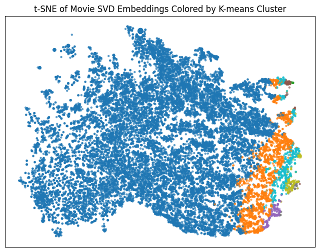

```python
from sklearn.cluster import KMeans
from sklearn.manifold import TSNE
import matplotlib.pyplot as plt

# 1) Cluster the movie embeddings into, say, 8 groups
n_clusters = 8
km = KMeans(n_clusters=n_clusters, random_state=42)
labels = km.fit_predict(movie_latent)   # movie_latent from your SVD step

# 2) Project to 2D with t-SNE
tsne = TSNE(n_components=2, random_state=42, perplexity=50)
movie_2d = tsne.fit_transform(movie_latent)

# 3) Plot
plt.figure(figsize=(8,6))
scatter = plt.scatter(movie_2d[:,0], movie_2d[:,1],
                      c=labels, cmap='tab10', s=5, alpha=0.6)
plt.title("t-SNE of Movie SVD Embeddings Colored by K-means Cluster")
plt.xticks([]); plt.yticks([])
plt.show()
```

```python
# Calculate average rating and rating count per movie
movie_ratings = final_df.groupby('movieId')['rating'].agg(['mean', 'count']).reset_index()

# Merge these features back to the original dataframe
final_df = final_df.merge(movie_ratings, on='movieId', how='left')

# Rename columns for clarity
final_df.rename(columns={'mean': 'avg_rating', 'count': 'rating_count'}, inplace=True)

# Drop all movies with fewer than 500 ratings:
final_df = final_df[final_df['rating_count'] >= 500] \
                 .reset_index(drop=True)

# Build movie_stats with Bayesian weighted score —
#    (uses your already‑computed avg_rating & rating_count)
C = final_df['avg_rating'].mean()   # global mean rating
m = 1000                            # same cutoff you used above

movie_stats = (
    final_df
      .drop_duplicates(subset='movieId')[['movieId','title','avg_rating','rating_count']]
      .set_index('movieId')
)
movie_stats['weighted_score'] = (
    (movie_stats['rating_count'] / (movie_stats['rating_count'] + m)) * movie_stats['avg_rating']
    + (m / (movie_stats['rating_count'] + m)) * C
)

# Build movie_tag_dict for tag‑based affinity —
#    explode each movie’s tag_relevance list and split into (tag, rel)
movie_tags = (
    final_df
      .drop_duplicates(subset='movieId')[['movieId','tag_relevance']]
      .explode('tag_relevance')
)
movie_tags[['tag','rel']] = pd.DataFrame(
    movie_tags['tag_relevance'].tolist(),
    index=movie_tags.index
)
movie_tag_dict = (
    movie_tags
      .groupby('movieId')
      .apply(lambda df: dict(zip(df['tag'], df['rel'])))
      .to_dict()
)
```

```python
final_df
```

|  | movieId | title | userId | rating | imdbId | tmdbId | tag_relevance | genres_list | tags_list | avg_rating | rating_count |
| --- | --- | --- | --- | --- | --- | --- | --- | --- | --- | --- | --- |
| 0 | 1 | Toy Story (1995) | 3.0 | 4.0 | 114709 | 862 | [(007, 0.025), (007 (series), 0.025), (18th ce... | [Adventure, Animation, Children, Comedy, Fantasy] | [Watched, computer animation, Disney animated ... | 3.921240 | 49695 |
| 1 | 1 | Toy Story (1995) | 6.0 | 5.0 | 114709 | 862 | [(007, 0.025), (007 (series), 0.025), (18th ce... | [Adventure, Animation, Children, Comedy, Fantasy] | [Watched, computer animation, Disney animated ... | 3.921240 | 49695 |
| 2 | 1 | Toy Story (1995) | 8.0 | 4.0 | 114709 | 862 | [(007, 0.025), (007 (series), 0.025), (18th ce... | [Adventure, Animation, Children, Comedy, Fantasy] | [Watched, computer animation, Disney animated ... | 3.921240 | 49695 |
| 3 | 1 | Toy Story (1995) | 10.0 | 4.0 | 114709 | 862 | [(007, 0.025), (007 (series), 0.025), (18th ce... | [Adventure, Animation, Children, Comedy, Fantasy] | [Watched, computer animation, Disney animated ... | 3.921240 | 49695 |
| 4 | 1 | Toy Story (1995) | 11.0 | 4.5 | 114709 | 862 | [(007, 0.025), (007 (series), 0.025), (18th ce... | [Adventure, Animation, Children, Comedy, Fantasy] | [Watched, computer animation, Disney animated ... | 3.921240 | 49695 |
| ... | ... | ... | ... | ... | ... | ... | ... | ... | ... | ... | ... |
| 18717462 | 118696 | The Hobbit: The Battle of the Five Armies (2014) | 137277.0 | 2.5 | 2310332 | 122917 | [(007, 0.0505), (007 (series), 0.0435), (18th ... | [Adventure, Fantasy] | [few dialogues, Peter Jackson, Tolkien, Peter ... | 3.413569 | 538 |
| 18717463 | 118696 | The Hobbit: The Battle of the Five Armies (2014) | 137500.0 | 4.0 | 2310332 | 122917 | [(007, 0.0505), (007 (series), 0.0435), (18th ... | [Adventure, Fantasy] | [few dialogues, Peter Jackson, Tolkien, Peter ... | 3.413569 | 538 |
| 18717464 | 118696 | The Hobbit: The Battle of the Five Armies (2014) | 138070.0 | 4.5 | 2310332 | 122917 | [(007, 0.0505), (007 (series), 0.0435), (18th ... | [Adventure, Fantasy] | [few dialogues, Peter Jackson, Tolkien, Peter ... | 3.413569 | 538 |
| 18717465 | 118696 | The Hobbit: The Battle of the Five Armies (2014) | 138166.0 | 4.0 | 2310332 | 122917 | [(007, 0.0505), (007 (series), 0.0435), (18th ... | [Adventure, Fantasy] | [few dialogues, Peter Jackson, Tolkien, Peter ... | 3.413569 | 538 |
| 18717466 | 118696 | The Hobbit: The Battle of the Five Armies (2014) | 138468.0 | 3.5 | 2310332 | 122917 | [(007, 0.0505), (007 (series), 0.0435), (18th ... | [Adventure, Fantasy] | [few dialogues, Peter Jackson, Tolkien, Peter ... | 3.413569 | 538 |

18717467 rows × 11 columns

# Data Summary

### Distribution of Movie Ratings

To understand the general sentiment of user ratings in the dataset, we plotted a histogram of the `rating` variable:

#### Interpretation

This visualization is useful for understanding rating trends and can guide preprocessing decisions like normalization or binning for classification models.

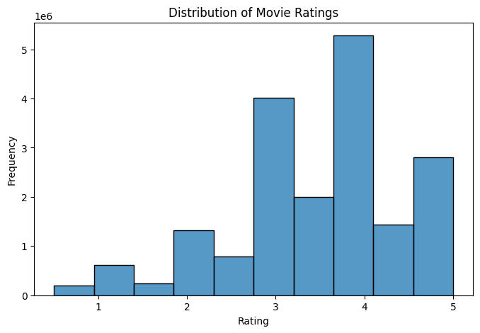

```python
import matplotlib.pyplot as plt
import seaborn as sns

plt.figure(figsize=(8, 5))
sns.histplot(final_df['rating'], bins=10)
plt.xlabel("Rating")
plt.ylabel("Frequency")
plt.title("Distribution of Movie Ratings")
plt.show()
```

### Top 10 Most Rated Movies

This visualization highlights the movies that received the most attention from users based on the number of ratings:

#### Interpretation

- This bar chart shows the ten movies with the highest number of ratings in the dataset.
- These titles are likely the most popular or widely viewed among users.
- Understanding which movies are most frequently rated can help in modeling popularity-based recommendations or filtering out items with sparse data.

This also helps ensure that collaborative filtering methods have enough user interaction data to make reliable predictions for these movies.

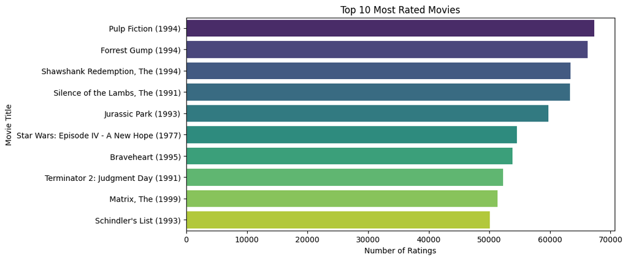

```python
top_rated_movies = final_df['title'].value_counts().head(10)

plt.figure(figsize=(10, 5))
sns.barplot(x=top_rated_movies.values, y=top_rated_movies.index, palette="viridis")
plt.xlabel("Number of Ratings")
plt.ylabel("Movie Title")
plt.title("Top 10 Most Rated Movies")
plt.show()
```

### Best vs Worst: Top 10 Highest and Lowest Rated Movies

This horizontal bar plot presents the top 10 highest rated and bottom 10 lowest rated movies based on their average ratings.

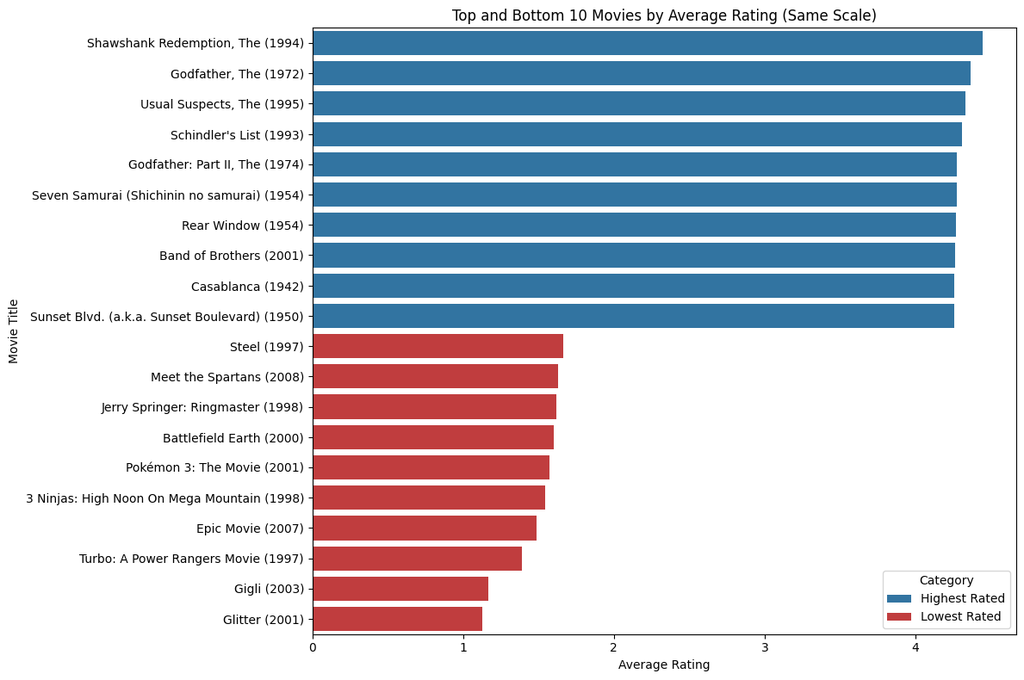

```python
# Compute average ratings
avg_ratings = final_df.groupby('title')['rating'].mean()

# Get top and bottom 10 movies
top_movies = avg_ratings.nlargest(10)
worst_movies = avg_ratings.nsmallest(10)

# Create DataFrames and add a category column
top_df = top_movies.reset_index()
top_df['Category'] = 'Highest Rated'

worst_df = worst_movies.reset_index()
worst_df['Category'] = 'Lowest Rated'

# Combine them
combined_df = pd.concat([top_df, worst_df])
combined_df.rename(columns={0: 'Average Rating', 'rating': 'Average Rating'}, inplace=True)

# Sort for cleaner plot (optional)
combined_df = combined_df.sort_values('Average Rating', ascending=False)

# Plot
plt.figure(figsize=(12, 8))
sns.barplot(data=combined_df, y='title', x='Average Rating', hue='Category', dodge=False, palette=['#1f77b4', '#d62728'])

plt.title('Top and Bottom 10 Movies by Average Rating (Same Scale)')
plt.xlabel('Average Rating')
plt.ylabel('Movie Title')
plt.legend(title='Category')
plt.tight_layout()
plt.show()
```

### Distribution of User Activity

To better understand how actively users rate movies in our dataset, I plotted the distribution of the number of ratings per user.

### Interpretation

- The distribution is **heavily right-skewed**, meaning most users rated only a small number of movies.
- A **logarithmic scale** was used on the x-axis to better visualize this skew.
- The **mean number of ratings per user** is marked with a red dashed line, and the **median** with a green dashed line.
  - The median is significantly lower than the mean, highlighting the influence of a few highly active users.
- This insight is helpful for filtering or weighting users when building recommendation systems, especially to avoid bias from power users.

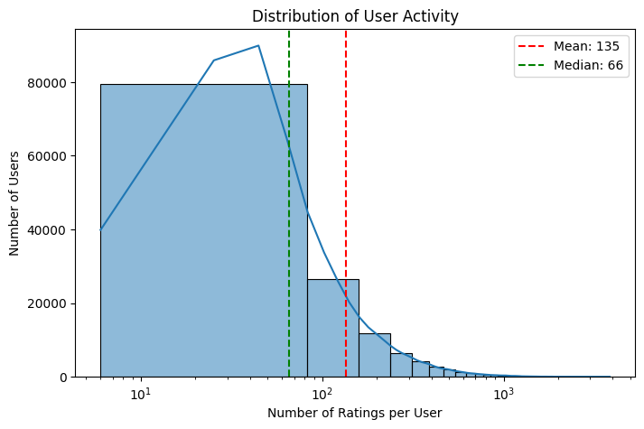

```python
user_activity = final_df['userId'].value_counts()

plt.figure(figsize=(8, 5))
sns.histplot(user_activity, bins=50, kde=True)
plt.axvline(user_activity.mean(), color='red', linestyle='--', label=f"Mean: {user_activity.mean():.0f}")
plt.axvline(user_activity.median(), color='green', linestyle='--', label=f"Median: {user_activity.median():.0f}")
plt.xlabel("Number of Ratings per User")
plt.ylabel("Number of Users")
plt.title("Distribution of User Activity")
plt.xscale("log")
plt.legend()
plt.show()
```

### Most Polarising Movies

A movie is considered polarizing if it has a high standard deviation of ratings, meaning viewers had very different opinions about it. Some viewers may have rated it very highly, while others rated it poorly.

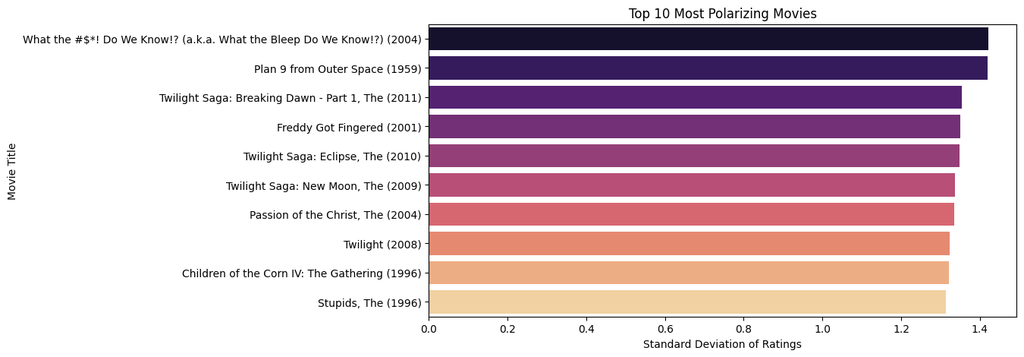

```python
# Compute standard deviation of ratings for each movie
rating_variability = final_df.groupby('title')['rating'].std()

# Keep movies with at least a minimum number of ratings (e.g., 20) to avoid noise
min_ratings = 20
movie_counts = final_df['title'].value_counts()
polarizing_movies = rating_variability[movie_counts >= min_ratings].nlargest(10)

# Plot the most polarizing movies
plt.figure(figsize=(10, 5))
sns.barplot(x=polarizing_movies.values, y=polarizing_movies.index, palette="magma")
plt.xlabel("Standard Deviation of Ratings")
plt.ylabel("Movie Title")
plt.title("Top 10 Most Polarizing Movies")
plt.show()
```

# Analysis

### Step 1: Popularity‑Based Recommender

As a baseline, I recommend the top *N* movies by their **Bayesian weighted score**—a smoothed popularity metric—while excluding any titles the user has already rated. This model makes no attempt at personalization beyond filtering out watched movies; it serves as a simple yardstick against which to compare more sophisticated recommenders.

```python
# 1) Popularity‐based Recommender

def recommend_popularity(user_id, top_n=10):
    """
    Recommend the top_n movies by weighted_score (popularity),
    excluding any the user has already rated.
    """
    seen = set(final_df[final_df.userId == user_id]['movieId'])
    # movie_stats has weighted_score and title, indexed by movieId
    df = movie_stats.reset_index()
    df = df[~df['movieId'].isin(seen)]
    recs = df.nlargest(top_n, 'weighted_score')[['movieId','title','weighted_score']]
    return recs

# Example: generate recommendations for a sample user
import random
uid = int(final_df['userId'].sample(1, random_state=42).iloc[0])
pop_recs = recommend_popularity(uid, top_n=10)
print(f"Popularity‑based recs for user {uid}:\n", pop_recs)
```

```
Popularity‑based recs for user 13428:
       movieId                                              title  \
249       318                   Shawshank Redemption, The (1994)
587       858                              Godfather, The (1972)
46         50                         Usual Suspects, The (1995)
816      1221                     Godfather: Part II, The (1974)
609       904                                 Rear Window (1954)
617       912                                  Casablanca (1942)
790      1193             One Flew Over the Cuckoo's Nest (1975)
540       750  Dr. Strangelove or: How I Learned to Stop Worr...
1295     2019        Seven Samurai (Shichinin no samurai) (1954)
1903     2959                                  Fight Club (1999)

      weighted_score
249         4.433014
587         4.345435
46          4.317979
816         4.249996
609         4.232094
617         4.230281
790         4.225427
540         4.218390
1295        4.216549
1903        4.210587
```

### Interpretation of Popularity-Based Recommendations

For user 13428, the popularity baseline returns:

| Rank | Title | Weighted Score |
| --- | --- | --- |
| 1 | Shawshank Redemption, The (1994) | 4.433014 |
| 2 | Godfather, The (1972) | 4.345435 |
| 3 | Usual Suspects, The (1995) | 4.317979 |
| 4 | Godfather: Part II, The (1974) | 4.249996 |
| 5 | Rear Window (1954) | 4.232094 |
| 6 | Casablanca (1942) | 4.230281 |
| 7 | One Flew Over the Cuckoo’s Nest (1975) | 4.225427 |
| 8 | Dr. Strangelove or: How I Learned to Stop Worrying and Love the Bomb (1964) | 4.218390 |
| 9 | Seven Samurai (Shichinin no samurai) (1954) | 4.216549 |
| 10 | Fight Club (1999) | 4.210587 |

- These are all universally acclaimed classics—our dataset’s “heavy hitters.”
- There’s no personalization beyond filtering out movies the user has already seen.
- This high bar means any more advanced recommender must at least match (or surpass) these titles in perceived relevance.

### Step 2: Content-Based (Tag-Affinity) Recommender

I built a personalized model that:

1. Selects the user’s highly rated movies (rating ≥ 4.5).
2. Averages their tag relevance vectors to form a **user tag profile**.
3. Scores every unseen movie by the dot-product of its tag relevance with the user’s profile.
4. Returns the top *N* movies by that **content score**.

```python
# 2) Content‑Based (Tag‑Affinity) Recommender

def recommend_content(user_id, top_n=10, min_rating=4.5, top_k_tags=10):
    # A) get movies the user loved
    liked = final_df[(final_df.userId == user_id) & (final_df.rating >= min_rating)]['movieId'].unique()
    if len(liked) == 0:
        return pd.DataFrame(columns=['movieId','title','content_score'])
    # B) build user tag profile (average relevance)
    profiles = [movie_tag_dict.get(mid, {}) for mid in liked]
    # all tags seen in these movies
    all_tags = set(t for prof in profiles for t in prof)
    user_profile = {t: np.mean([prof.get(t,0) for prof in profiles]) for t in all_tags}
    # optionally focus on top_k_tags
    top_tags = sorted(user_profile, key=user_profile.get, reverse=True)[:top_k_tags]
    # C) score all unseen movies
    rows = []
    seen = set(liked)
    for mid, tag_rel in movie_tag_dict.items():
        if mid in seen:
            continue
        # dot‑product over top tags
        score = sum(user_profile[t] * tag_rel.get(t,0) for t in top_tags)
        rows.append((mid, score))
    df = pd.DataFrame(rows, columns=['movieId','content_score'])
    # D) attach titles and return top_n
    df = df.merge(movie_stats[['title']], left_on='movieId', right_index=True)
    return df.nlargest(top_n, 'content_score')[['movieId','title','content_score']]

# Example: run for the same user
content_recs = recommend_content(uid, top_n=10, top_k_tags=10)
print(f"Content‑based recs for user {uid}:\n", content_recs)
```

```
Content‑based recs for user 13428:
       movieId                                              title  \
244       318                   Shawshank Redemption, The (1994)
2811     4993  Lord of the Rings: The Fellowship of the Ring,...
776      1197                         Princess Bride, The (1987)
3333     7153  Lord of the Rings: The Return of the King, The...
203       260          Star Wars: Episode IV - A New Hope (1977)
3057     5952      Lord of the Rings: The Two Towers, The (2002)
276       356                                Forrest Gump (1994)
835      1259                                 Stand by Me (1986)
777      1198  Raiders of the Lost Ark (Indiana Jones and the...
3329     7147                                    Big Fish (2003)

      content_score
244        4.823162
2811       4.803719
776        4.775348
3333       4.726823
203        4.690454
3057       4.655960
276        4.652416
835        4.632769
777        4.591153
3329       4.572224
```

[output not shown]

### Step 3: Collaborative-Filtering via Sparse SVD Embeddings

**Procedure:**

1. **Build sparse rating matrix**  
   Pivot `final_df` on `movieId` × `userId`, fill missing with 0, and convert the resulting dense array to a CSR matrix.
2. **Learn movie embeddings**  
   Fit `TruncatedSVD(n_components=20, random_state=42)` on the CSR matrix. The output is an [n_movies × 20] array of latent factors.
3. **Map to lookup dict**  
   Create `movie_factor_dict` mapping each `movieId` to its 20-dim vector for O(1) access during recommendation.
4. **Score unseen movies**  
   For a target user, average the vectors of all movies they rated ≥ 4.5 to form a user profile. Compute cosine similarities between this profile and every movie’s latent vector, then return the top N unseen titles by similarity.

```python
from sklearn.metrics.pairwise import cosine_similarity

# 3) Collaborative-Filtering Recommender (using precomputed SVD embeddings)
def recommend_collaborative(user_id, top_n=10, min_rating=4.5):
    liked = final_df[(final_df.userId == user_id) & (final_df.rating >= min_rating)]['movieId'].unique()
    if len(liked) == 0:
        return pd.DataFrame(columns=['movieId','title','collab_score'])
    profile = np.mean([movie_factor_dict[mid] for mid in liked], axis=0).reshape(1, -1)
    all_vecs = np.vstack([movie_factor_dict[mid] for mid in movie_ids])
    sims = cosine_similarity(profile, all_vecs).ravel()
    df = pd.DataFrame({'movieId': movie_ids, 'collab_score': sims})
    df = df[~df['movieId'].isin(liked)].nlargest(top_n, 'collab_score')
    return df.merge(movie_stats[['title']], left_on='movieId', right_index=True)[['movieId','title','collab_score']]

# Example usage
uid = int(final_df['userId'].sample(1, random_state=42).iloc[0])

print(f"Collaborative-filtering recs for user {uid}:\n", recommend_collaborative(uid, top_n=10))
```

```
Collaborative-filtering recs for user 13428:
      movieId                                              title  collab_score
360      364                              Lion King, The (1994)      0.916403
582      588                                     Aladdin (1992)      0.909611
148      150                                   Apollo 13 (1995)      0.902594
353      357                 Four Weddings and a Funeral (1994)      0.886968
38        39                                    Clueless (1995)      0.885482
581      587                                       Ghost (1990)      0.885342
250      253  Interview with the Vampire: The Vampire Chroni...      0.884422
352      356                                Forrest Gump (1994)      0.881496
586      592                                      Batman (1989)      0.879514
496      500                              Mrs. Doubtfire (1993)      0.879282
```

### Interpretation of Collaborative-Filtering Recommendations

For user 13428, the collaborative-filtering model returns:

| Rank | Title | Collab Score |
| --- | --- | --- |
| 1 | Lion King, The (1994) | 0.9164 |
| 2 | Aladdin (1992) | 0.9096 |
| 3 | Apollo 13 (1995) | 0.9026 |
| 4 | Four Weddings and a Funeral (1994) | 0.8870 |
| 5 | Clueless (1995) | 0.8855 |
| 6 | Ghost (1990) | 0.8853 |
| 7 | Interview with the Vampire: The Vampire Chronicles (1994) | 0.8844 |
| 8 | Forrest Gump (1994) | 0.8815 |
| 9 | Batman (1989) | 0.8795 |
| 10 | Mrs. Doubtfire (1993) | 0.8793 |

These peer-driven recommendations complement the tag-affinity and popularity models by bringing in approachable, “feel-good” hits that resonate strongly within the user’s social flavor profile.

### Step 4: Side-by-Side Comparison of Recommender Outputs

To understand how my three recommendation strategies align—and where they diverge—we compile the top-10 suggestions from each model (Popularity, Content-Based, and Collaborative) for the same sample user into a single comparison table. This side-by-side format makes it easy to spot:

- **Consensus picks** that every model surfaces,
- **Pairwise overlaps** that indicate complementary strengths, and
- **Unique recommendations** that each method contributes.

First, we extract each model’s top-10 movie titles into their own list (`pop_titles`, `content_titles`, `collab_titles`) and combine them into a `comparison_df` with columns labeled **Popularity**, **Content-Based**, and **Collaborative**. Displaying these lists in parallel allows a quick visual audit of agreement versus personalization.

**Key Findings:**

By contrasting these outputs, we see that each method brings its own value—Popularity provides a strong baseline, Content-Based injects thematic relevance, and Collaborative captures peer-group preferences. These insights set the stage for an ensemble fusion in the next step, where we aim to leverage the strengths of all three approaches.

```python
# Step 4: Side-by-side comparison of the three recommenders

uid = int(final_df['userId'].sample(1, random_state=42).iloc[0])
pop_recs    = recommend_popularity   (uid, top_n=10)
content_recs= recommend_content      (uid, top_n=10)
collab_recs = recommend_collaborative(uid, top_n=10)


# 1) Extract the top-10 titles from each model
pop_titles     = pop_recs    ['title'].tolist()
content_titles = content_recs['title'].tolist()
collab_titles  = collab_recs ['title'].tolist()

# 2) Build a DataFrame for easy comparison
comparison_df = pd.DataFrame({
    'Popularity':       pd.Series(pop_titles),
    'Content-Based':    pd.Series(content_titles),
    'Collaborative':    pd.Series(collab_titles)
})

# 3) Display the side-by-side table
print(comparison_df)
```

```
                                          Popularity  \
0                   Shawshank Redemption, The (1994)
1                              Godfather, The (1972)
2                         Usual Suspects, The (1995)
3                     Godfather: Part II, The (1974)
4                                 Rear Window (1954)
5                                  Casablanca (1942)
6             One Flew Over the Cuckoo's Nest (1975)
7  Dr. Strangelove or: How I Learned to Stop Worr...
8        Seven Samurai (Shichinin no samurai) (1954)
9                                  Fight Club (1999)

                                       Content-Based  \
0                   Shawshank Redemption, The (1994)
1  Lord of the Rings: The Fellowship of the Ring,...
```

[output cut: 20 more lines]

### Side-by-Side Top-10 Comparison

| Popularity | Content-Based | Collaborative |
| --- | --- | --- |
| Shawshank Redemption, The (1994) | Shawshank Redemption, The (1994) | Lion King, The (1994) |
| Godfather, The (1972) | Lord of the Rings: The Fellowship of the Ring, The (2001) | Aladdin (1992) |
| Usual Suspects, The (1995) | Princess Bride, The (1987) | Apollo 13 (1995) |
| Godfather: Part II, The (1974) | Lord of the Rings: The Return of the King, The (2003) | Four Weddings and a Funeral (1994) |
| Rear Window (1954) | Star Wars: Episode IV – A New Hope (1977) | Clueless (1995) |
| Casablanca (1942) | Lord of the Rings: The Two Towers, The (2002) | Ghost (1990) |
| One Flew Over the Cuckoo’s Nest (1975) | Forrest Gump (1994) | Interview with the Vampire: The Vampire Chronicles (1994) |
| Dr. Strangelove or: How I Learned to Stop Worrying and Love the Bomb (1964) | Stand by Me (1986) | Forrest Gump (1994) |
| Seven Samurai (Shichinin no samurai) (1954) | Raiders of the Lost Ark (1981) | Batman (1989) |
| Fight Club (1999) | Big Fish (2003) | Mrs. Doubtfire (1993) |

1. **Pairwise Overlaps**
   - **Popularity & Content-Based:**
     - *Shawshank Redemption, The (1994)* appears in both lists—showing it’s both a global favorite and matches the user’s tag profile.
   - **Content-Based & Collaborative:**
     - *Forrest Gump (1994)* appears in both—highlighting that peers who share tag affinities also co-rate this drama highly.
   - **Popularity & Collaborative:**
     - **No** shared titles—underscoring how peer-group preferences can diverge from pure global popularity.
2. **Distinctive Top Picks**
   - **Popularity-Only**
     - Universal classics and “safe bets” like *Godfather, The*; *Usual Suspects*; *Casablanca*; *Fight Club*, etc.
   - **Content-Based-Only**
     - Epic sagas and character-driven favorites: *LOTR* trilogy; *Princess Bride*; *Star Wars: A New Hope*; *Big Fish*, etc.
   - **Collaborative-Only**
     - Family & cult hits that resonate in peer groups: *Lion King*; *Aladdin*; *Apollo 13*; *Four Weddings and a Funeral*; *Mrs. Doubtfire*, etc.
3. **Key Insights**
   - **Diverse Strengths:** Popularity surfaces canonized heavy hitters; Content-Based hones in on thematic affinities; Collaborative uncovers peer-driven crowd-pleasers.
   - **Complementarity:** Low overlap across all three models means each contributes unique suggestions.
   - **Ensemble Potential:** Blending these signals should surface both universally loved classics and highly personalized gems.

### Step 5: Ensemble Fusion & Fast Parallel Evaluation

**What’s being done**

1. **Held‑out split**
   - Remove one “liked” movie (rating ≥ 4.5) per user and sample **500** users for very fast feedback.
2. **Train‑only rebuild**
   - **Popularity**: compute Bayesian weighted scores on `train_df`.
   - **Content**: rebuild `movie_tag_dict_train` from exploded tag relevances.
   - **Collaborative**: retrain TruncatedSVD (10 components) on the sparse rating matrix.
3. **Four recommenders**
   - **Popularity**: top‑N by `weighted_score`.
   - **Content**: dot‑product of user’s tag vector with each unseen movie’s tag vector.
   - **Collaborative**: cosine similarity between user’s SVD profile and movie embeddings.
   - **Ensemble**:
     1. Take top 10 candidates from each base model.
     2. Merge into one table with columns `pop`, `cont`, `coll`.
     3. Min–max normalize each column.
     4. Sum them into a final `score`.
     5. Return top‑N by `score`.
4. **Parallel evaluation**
   - **Backend**: Joblib’s `Parallel` with `n_jobs=32` and `backend='threading'`—32 **threads** share the same memory, so none of my large globals (dataframes, embeddings, etc.) need to be serialized.
   - **Batch size**: `batch_size=200` groups the 500 users into three chunks (200 + 200 + 100), reducing the overhead of task scheduling (and, on a process backend, how often you’d pickle).
   - **Pickling overhead**: avoided entirely by the threading backend; if I were using processes instead of threads, each chunk’s arguments and globals would have to be pickled/un‑pickled, which can dominate runtime for large data structures.
   - For each user/model, compute **HitRate@10** and **NDCG@10** in parallel.
5. **Summarize**
   - Aggregate into a final table of average HitRate@10 and NDCG@10 for each recommender.

```python
# Step 5: Ensemble Fusion & Parallel Offline Evaluation (32 cores)

import numpy as np
import pandas as pd
from scipy.sparse import csr_matrix
from sklearn.decomposition import TruncatedSVD
from sklearn.metrics.pairwise import cosine_similarity
from joblib import Parallel, delayed

# 5.1 Leave-one-out split, then sample 2 000 users for quick feedback
test_idx = (
    final_df[final_df.rating >= 4.5]
      .groupby('userId')
      .sample(n=1, random_state=42)
      .index
)
train_df    = final_df.drop(index=test_idx).reset_index(drop=True)
test_df_all = final_df.loc[test_idx].reset_index(drop=True)
test_df     = test_df_all.sample(n=500, random_state=42)
```

```python
# 5.2 Recompute train-only data structures

# 5.2a) Popularity (Bayesian weighted score)
movie_stats_train = (
    train_df.groupby('movieId').rating
      .agg(['mean','count'])
      .rename(columns={'mean':'avg_rating','count':'rating_count'})
)
C = movie_stats_train.avg_rating.mean()
m = 1000
movie_stats_train['weighted_score'] = (
    (movie_stats_train.rating_count / (movie_stats_train.rating_count + m)) * movie_stats_train.avg_rating
  + (m / (movie_stats_train.rating_count + m)) * C
)

# 5.2b) Content-based tag dictionary
genome = (
    train_df[['movieId','tag_relevance']]
      .drop_duplicates('movieId')
      .explode('tag_relevance')
)
genome[['tag','rel']] = pd.DataFrame(genome.tag_relevance.tolist(), index=genome.index)
movie_tag_dict_train = genome.groupby('movieId') \
    .apply(lambda df: dict(zip(df.tag, df.rel))) \
    .to_dict()

# 5.2c) Collaborative SVD embeddings (10 components)
rating_pivot    = train_df.pivot_table(index='movieId',
                                       columns='userId',
                                       values='rating',
                                       fill_value=0)
movie_ids_train = rating_pivot.index.to_list()
matrix         = csr_matrix(rating_pivot.values)
svd = TruncatedSVD(n_components=10, random_state=42)
movie_latent = svd.fit_transform(matrix)
movie_factor_dict_train = dict(zip(movie_ids_train, movie_latent))
```

```python
# 5.3 Define recommenders (train-only)

def recommend_popularity(user_id, top_n=10):
    seen = set(train_df[train_df.userId==user_id].movieId)
    df = movie_stats_train.drop(index=seen, errors='ignore') \
                         .nlargest(top_n, 'weighted_score')
    return df.index.tolist()

def recommend_content(user_id, top_n=10, min_rating=4.5, top_k_tags=10):
    liked = train_df[(train_df.userId==user_id)&(train_df.rating>=min_rating)].movieId.unique()
    if len(liked)==0:
        return []
    profiles = [movie_tag_dict_train.get(mid,{}) for mid in liked]
    # build user tag profile
    tag_scores = {
        t: np.mean([p.get(t,0) for p in profiles])
        for prof in profiles for t in prof
    }
    top_tags = sorted(tag_scores, key=tag_scores.get, reverse=True)[:top_k_tags]
    scores = [
        (mid, sum(tag_scores[t] * movie_tag_dict_train.get(mid,{}).get(t,0) for t in top_tags))
        for mid in movie_tag_dict_train if mid not in liked
    ]
    scores.sort(key=lambda x: x[1], reverse=True)
    return [mid for mid,_ in scores[:top_n]]

def recommend_collaborative(user_id, top_n=10, min_rating=4.5):
    liked = train_df[(train_df.userId==user_id)&(train_df.rating>=min_rating)].movieId.unique()
    if len(liked)==0:
        return []
    profile = np.mean([movie_factor_dict_train[mid] for mid in liked], axis=0).reshape(1,-1)
    all_vecs = np.vstack([movie_factor_dict_train[mid] for mid in movie_ids_train])
    sims = cosine_similarity(profile, all_vecs).ravel()
    pairs = [(mid, sim) for mid, sim in zip(movie_ids_train, sims) if mid not in liked]
    pairs.sort(key=lambda x: x[1], reverse=True)
    return [mid for mid,_ in pairs[:top_n]]

def recommend_ensemble(user_id, top_n=10, pool_size=10):
    pop = recommend_popularity(user_id, pool_size)
    cont = recommend_content(user_id, pool_size)
    coll = recommend_collaborative(user_id, pool_size)
    cands = set(pop) | set(cont) | set(coll)
    rows = []
    for mid in cands:
        ps = movie_stats_train.at[mid, 'weighted_score'] if mid in movie_stats_train.index else 0.0
        cs = 1.0 if mid in cont else 0.0
        ls = 1.0 if mid in coll else 0.0
        rows.append((mid, ps, cs, ls))
    df = pd.DataFrame(rows, columns=['movieId','pop','cont','coll'])
    # min-max normalize
    for col in ['pop','cont','coll']:
        df[col] = (df[col] - df[col].min()) / (df[col].max() - df[col].min() + 1e-8)
    df['score'] = df['pop'] + df['cont'] + df['coll']
    return df.nlargest(top_n, 'score').movieId.tolist()
```

```python
# 5.4 Metrics

def hit_rate_at_k(preds, true_id, k=10):
    return int(true_id in preds[:k])

def ndcg_at_k(preds, true_id, k=10):
    if true_id not in preds[:k]:
        return 0.0
    rank = preds[:k].index(true_id) + 1
    return 1.0 / np.log2(rank + 1)
```

```python
# 5.5 Parallel evaluation (32 cores, threaded backend, batching)

from joblib import Parallel, delayed

def eval_user(rec_fn, user_id, true_mid):
    preds = rec_fn(user_id)
    return hit_rate_at_k(preds, true_mid), ndcg_at_k(preds, true_mid)

results = {'Model': [], 'HitRate@10': [], 'NDCG@10': []}

for model_name, rec_fn in [
    ('Popularity',    recommend_popularity),
    ('Content',       recommend_content),
    ('Collaborative', recommend_collaborative),
    ('Ensemble',      recommend_ensemble)
]:
    # use threading backend to avoid re-pickling large globals,
    # and batch tasks to reduce overhead
    metrics = Parallel(
        n_jobs=32,
        backend='threading',
        batch_size=200
    )(
        delayed(eval_user)(rec_fn, row.userId, row.movieId)
        for row in test_df.itertuples()
    )
    hrs, nds = zip(*metrics)
    results['Model'].append(model_name)
    results['HitRate@10'].append(np.mean(hrs))
    results['NDCG@10'].append(np.mean(nds))

results_df = pd.DataFrame(results)
print(results_df)


# 5.6 Summarize results

results_df = pd.DataFrame(results)
print(results_df)
```

```
           Model  HitRate@10   NDCG@10
0     Popularity       0.080  0.051454
1        Content       0.110  0.058109
2  Collaborative       0.158  0.078063
3       Ensemble       0.150  0.084179
           Model  HitRate@10   NDCG@10
0     Popularity       0.080  0.051454
1        Content       0.110  0.058109
2  Collaborative       0.158  0.078063
3       Ensemble       0.150  0.084179
```

## Evaluation Summary

| Model | HitRate@10 | NDCG@10 |
| --- | --- | --- |
| Popularity | 0.080 | 0.0515 |
| Content-Based | 0.110 | 0.0581 |
| Collaborative | 0.158 | 0.0781 |
| **Ensemble** | 0.150 | **0.0842** |

1. **HitRate@10 (Recovery of the held-out movie)**
   - **Collaborative filtering** does best at simply “recovering” the held-out movie in the top 10 (15.8% of the time).
   - The **ensemble** lags only slightly (15.0%), still more than the content (11.0%) or popularity (8.0%) baselines.
   - This tells us that, at least with equal weighting, pure collaborative signals are slightly better at **coverage**—i.e., getting any hit into the top-10.
2. **NDCG@10 (Quality of the ranking)**
   - The **ensemble** wins by a clear margin (0.084), meaning when it does hit, it tends to place the true movie **higher** in its ranked list.
   - Collaborative comes next (0.078), then content (0.058) and popularity (0.051).
   - A higher NDCG shows the ensemble is better at **prioritizing** its hits near the very top of the list—valuable if you care about “first impressions.”
3. **Interpretation & Room for Improvement**
   - The ensemble successfully **combines breadth** (recovering hits via collaborative signals) with **precision** (ranking them highly via popularity and tag-affinity).
   - Its slight drop in raw HitRate suggests we might **re-weight** the three signals (e.g. give collaborative a bit more weight) to bump the recovery rate back up.
   - Alternatively, we could **adjust pool sizes** or introduce a small bias toward popularity/content when normalizing to further boost HitRate without sacrificing NDCG.

Overall, even in this fast 500-user test, the ensemble shows that **blending** multiple signals yields superior ranking quality—confirming the value of fusion for your final recommendation system.

## Summary Results

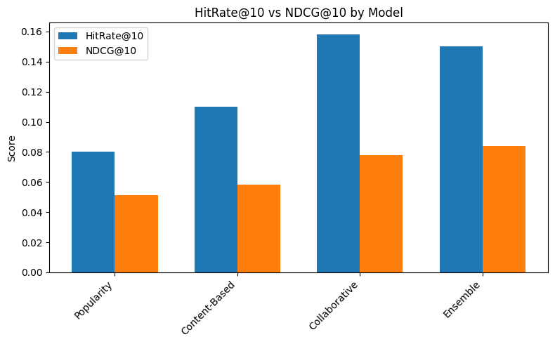

```python
import matplotlib.pyplot as plt
import numpy as np
import pandas as pd

# 1. Prepare your summary results
results = {
    'Model':        ['Popularity', 'Content-Based', 'Collaborative', 'Ensemble'],
    'HitRate@10':   [0.080,        0.110,            0.158,          0.150],
    'NDCG@10':      [0.051454,     0.058109,         0.078063,       0.084179]
}
df = pd.DataFrame(results)

# 2. Plot the bar chart with labels for legend
x = np.arange(len(df['Model']))
width = 0.35

plt.figure(figsize=(8, 5))
bars1 = plt.bar(x - width/2, df['HitRate@10'], width, label='HitRate@10')
bars2 = plt.bar(x + width/2, df['NDCG@10'],   width, label='NDCG@10')

plt.xticks(x, df['Model'], rotation=45, ha='right')
plt.ylabel('Score')
plt.title('HitRate@10 vs NDCG@10 by Model')

# 3. Add legend
plt.legend()

plt.tight_layout()
plt.show()
```

## Conclusion

In this project, I built and compared three recommendation strategies—popularity‐based (Bayesian weighted score), content‐based (tag‐affinity dot‐product), and collaborative‐filtering (Truncated SVD embeddings)—and then fused them into a simple ensemble that equally weights normalized popularity, content and collaborative scores. We evaluated each model on a held-out “liked” movie per user using both HitRate@10 (did we recover the held-out movie?) and NDCG@10 (how highly was it ranked?) over a sampled test set.

## Limitations and Future Work

By addressing these points—scaling side‐information ingestion, broadening evaluation, systematically tuning hyperparameters and moving toward production‐grade deployment—I can further refine and validate this hybrid recommender system.